# PROXIOME EXPERIMENT SUMMARY

**B**

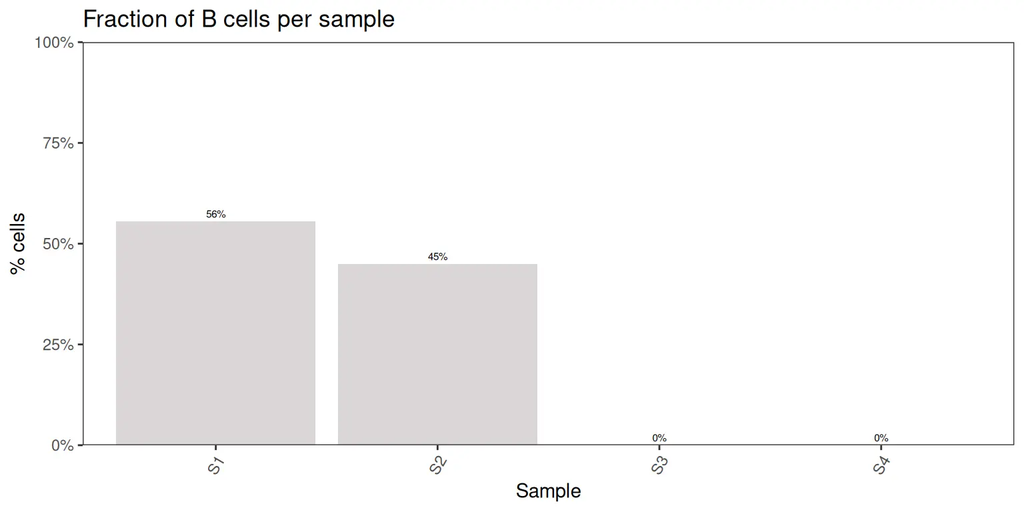

**Platelets**

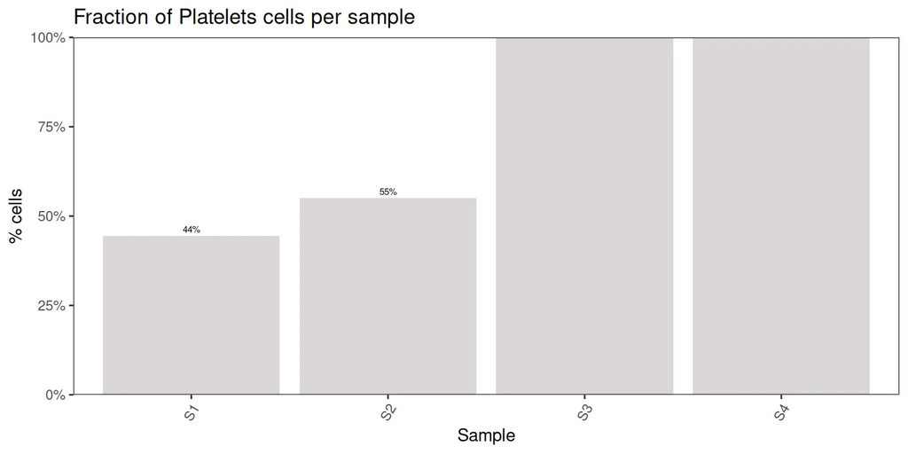

**UMAP**

**Level 1 annotation**

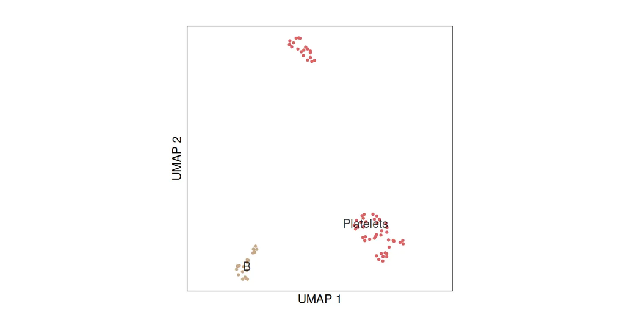

**Level 2 annotation**

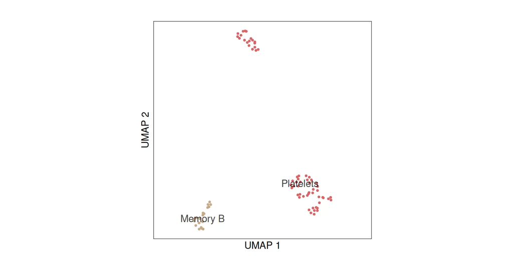

**Cluster abundance heatmap**

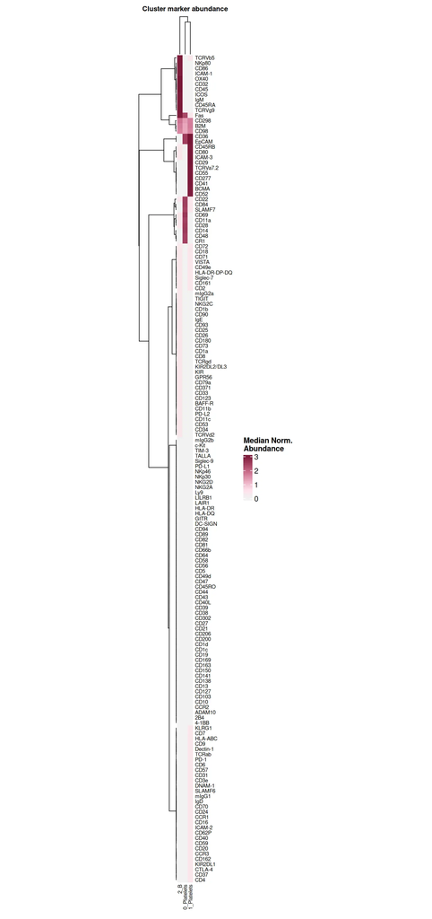

**Doublet estimation**

We can also estimate doublets in the data using a simple simulation-based approach. If a component has more simulated doublets as nearest neighbors (in a PCA space) than expected by random chance, it is classified as a doublet (p < 0.05). Please note that doublet prediction is an experimental feature that has yet to go through evaluation.

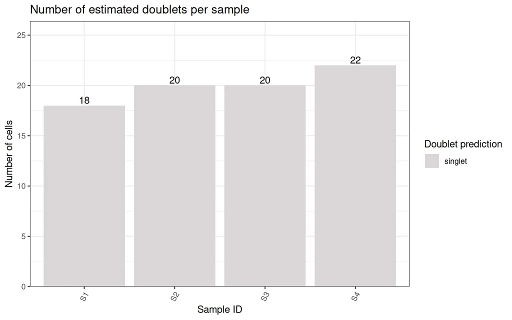

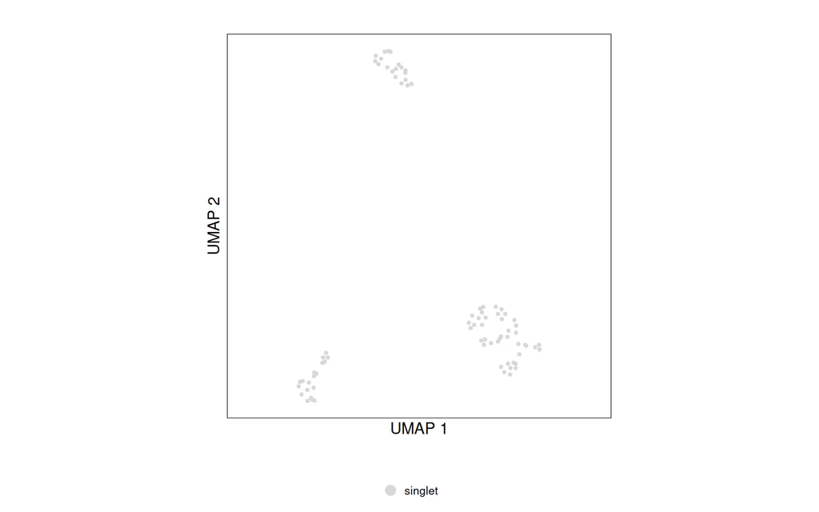

**Abundance**

This plot summarizes the partitioning of variance in marker abundance across cell types and samples. For each marker, omega squared (ω²) quantifies the proportion of variance explained by cell type identity (x-axis) and sample-related effects (y-axis, including sample and sample × cell type interaction). A high ω² value for the cell type identity indicates that there are large differences in marker abundance between cell types, while a high ω² value for the sample-related effects indicates that there are large differences in marker abundance between samples; either for the whole sample, or for certain cell types. The dashed line represents the boundary, as total ω² cannot exceed 1.

**Figure**

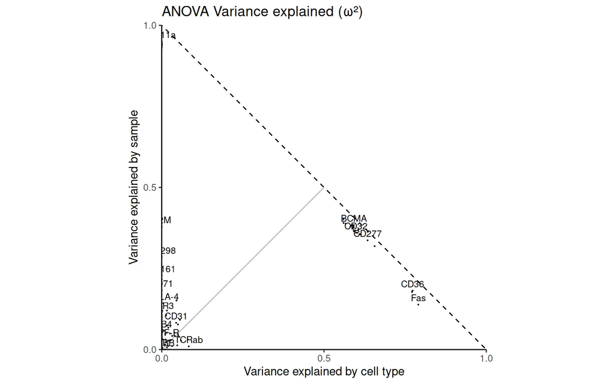

### Abundance

**CD8**

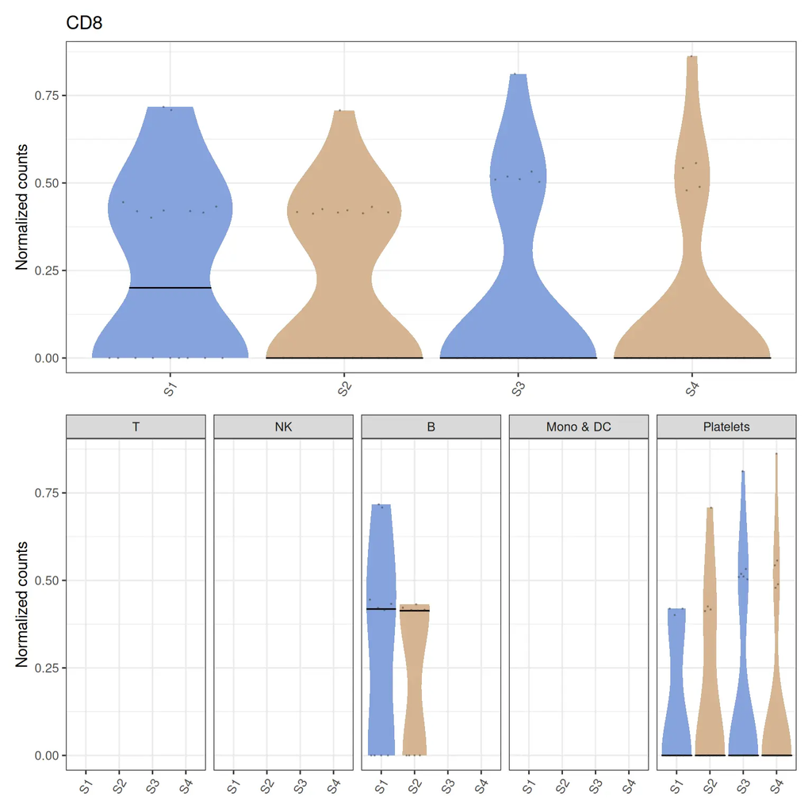

**CD11b**

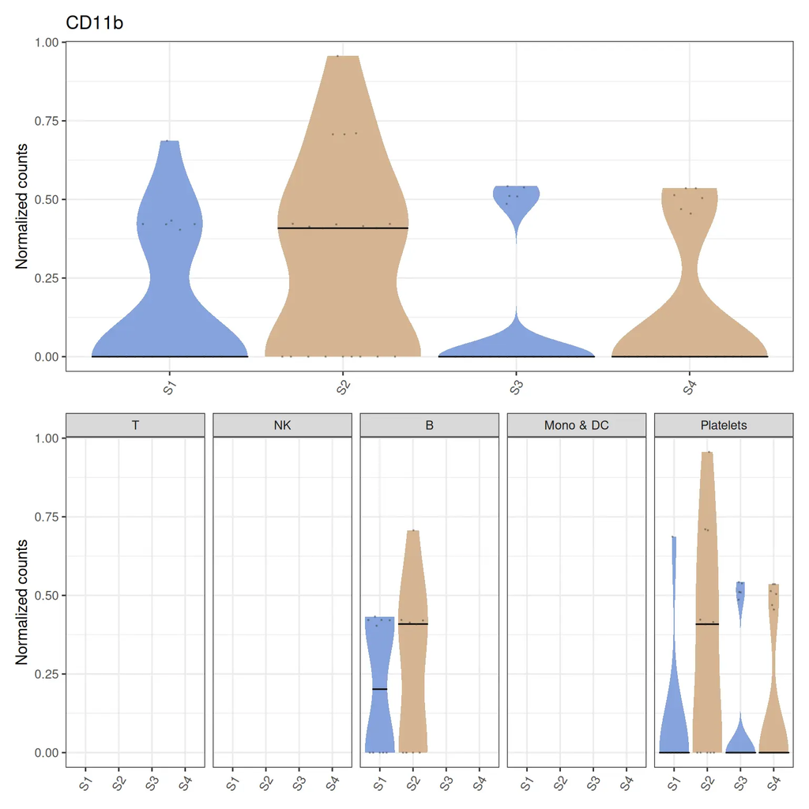

**CD11c**

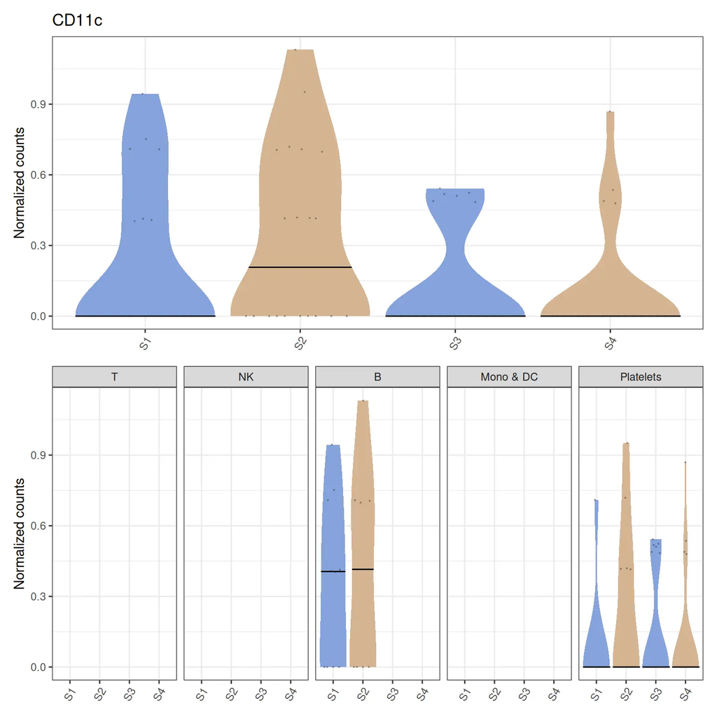

**CD18**

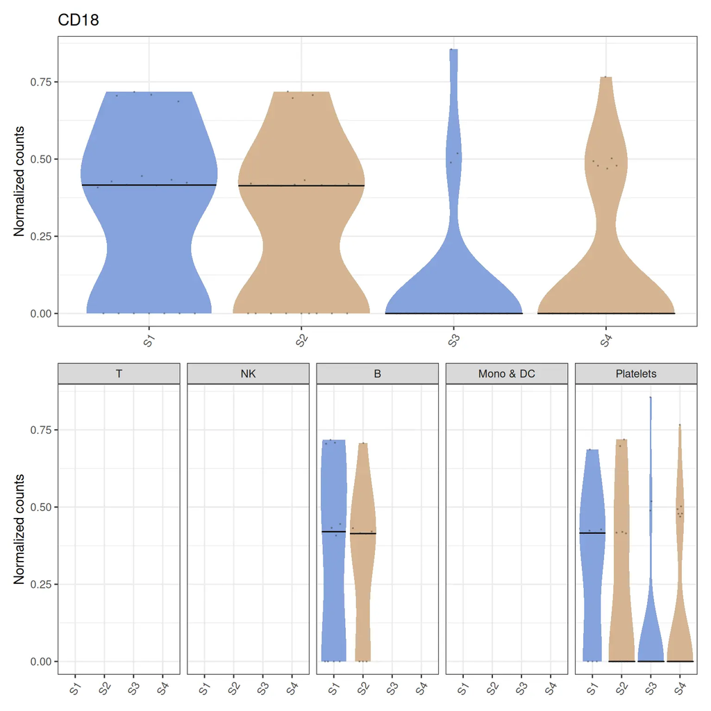

**CD45**

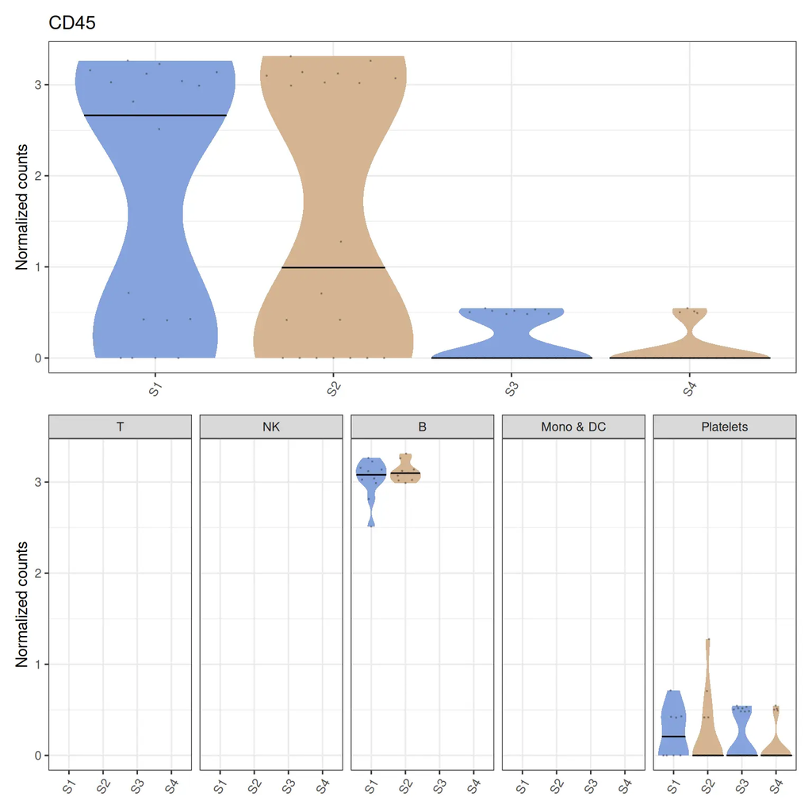

**CD82**

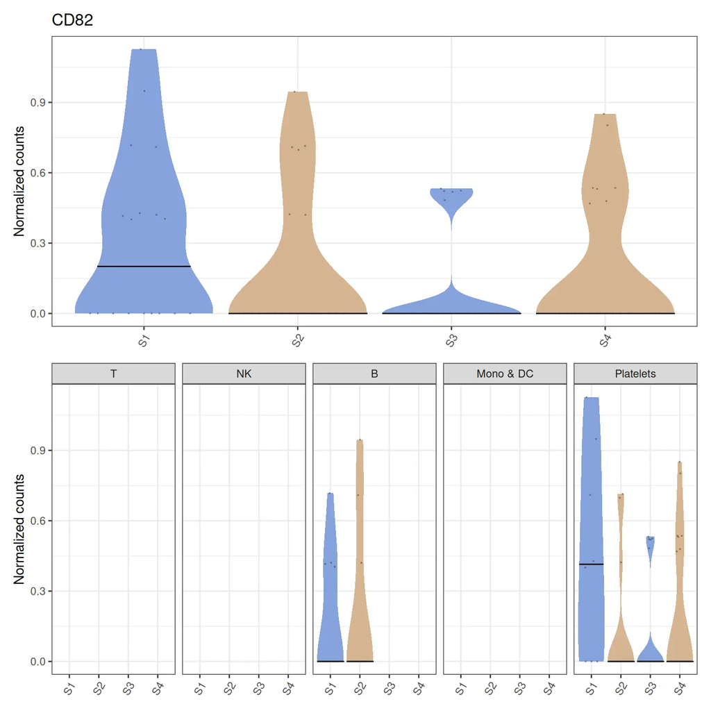

**B2M**

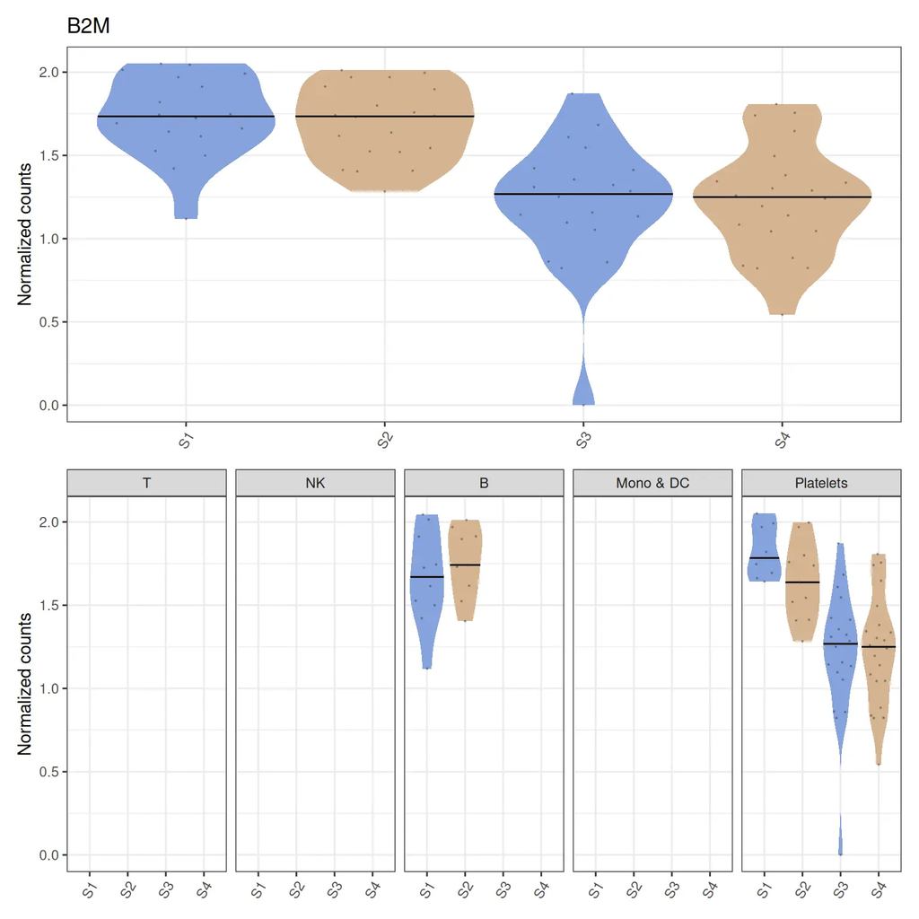

**HLA-ABC**

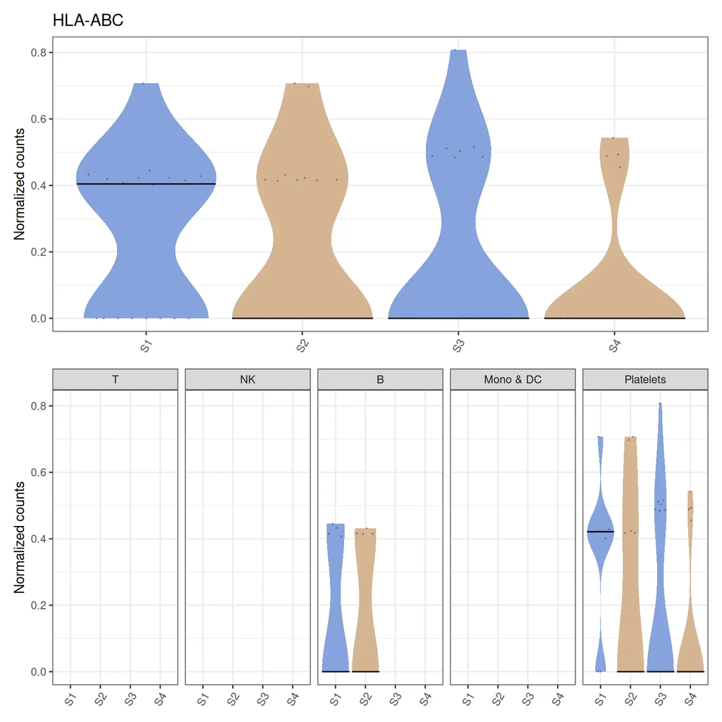

**HLA-DR**

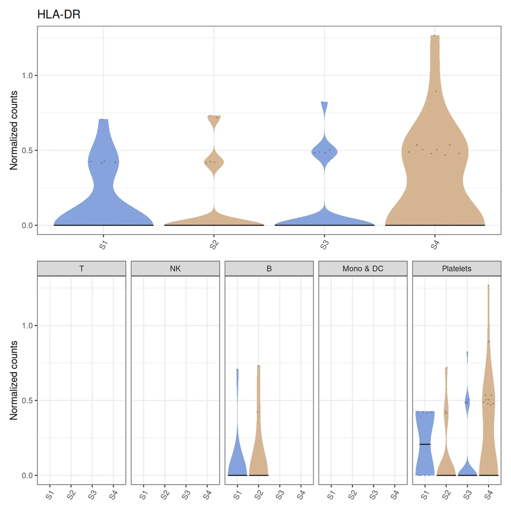

**TCRab**

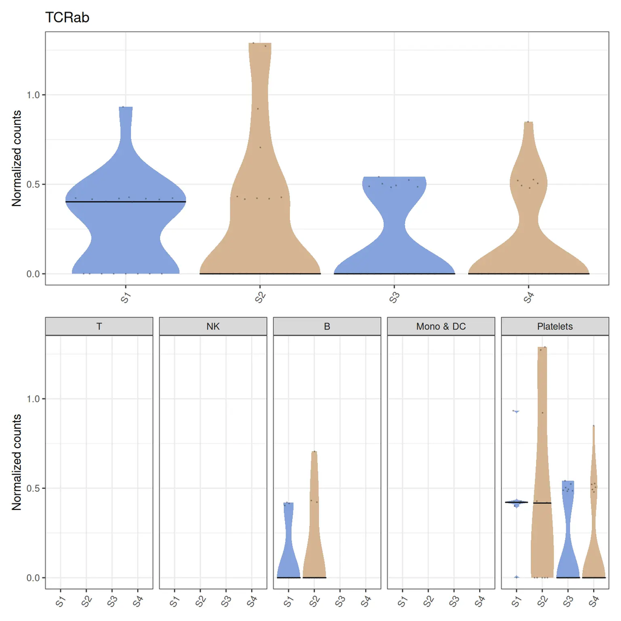

**Spatial metrics**

This plot summarizes the partitioning of variance in marker proximity score across cell types and samples. For each marker, omega squared (ω²) quantifies the proportion of variance explained by cell type identity (x-axis) and sample-related effects (y-axis, including sample and sample × cell type interaction). A high ω² value for the cell type identity indicates that there are large differences in marker proximity score between cell types, while a high ω² value for the sample-related effects indicates that there are large differences in marker proximity score between samples; either for the whole sample, or for certain cell types. The dashed line represents the boundary, as total ω² cannot exceed 1.

**Figure**

[figure not shown]

### Spatial metrics

In PNA, each cell is represented as a graph where proteins are nodes and edges reflect spatial proximity. For each protein pair, the observed number of edges (join count) is compared to the expected number under random permutations, which account for protein abundance.

The **log2 ratio** Proximity Score summarizes this comparison as the log2-transformed ratio of observed to expected counts. A value of **+1** means twice as many edges as expected by chance, while **−1** means half as many. This provides an intuitive measure of spatial correlation, highlighting patterns such as clustering or colocalization.

Learn more at [PNA Proximity Scores](https://software.pixelgen.com/pixelator/algorithms/#pna-proximity-scores).

**Clustering**

**CD11a**

[figure not shown]

**CD14**

[figure not shown]

**CD22**

[figure not shown]

**CD28**

[figure not shown]

**CD29**

[figure not shown]

**CD32**

[figure not shown]

**CD36**

[figure not shown]

**CD41**

[figure not shown]

**CD45**

[figure not shown]

**CD45RA**

[figure not shown]

**Colocalization**

**Global**

**S1**

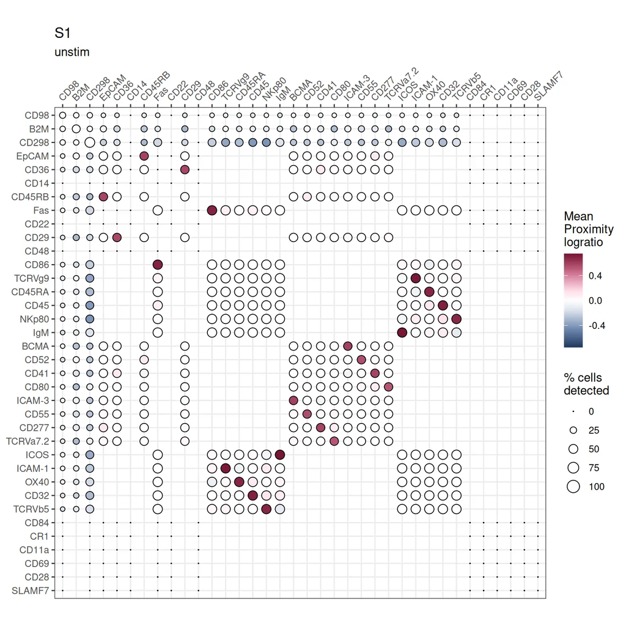

**S2**

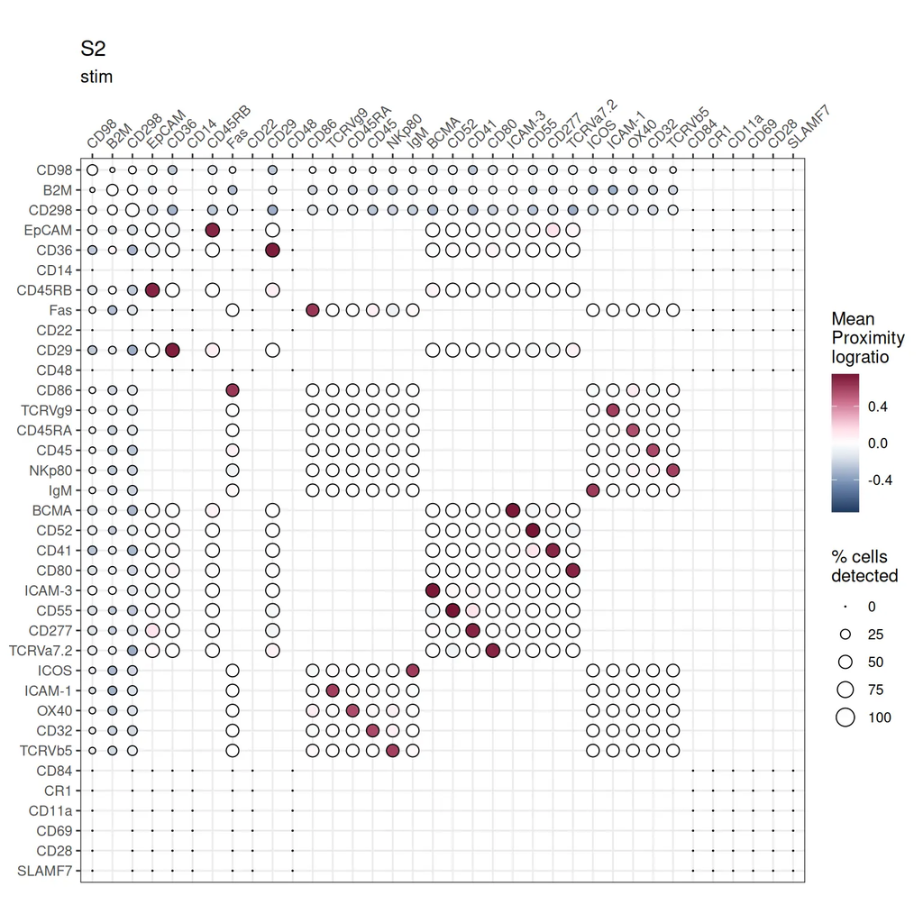

**S3**

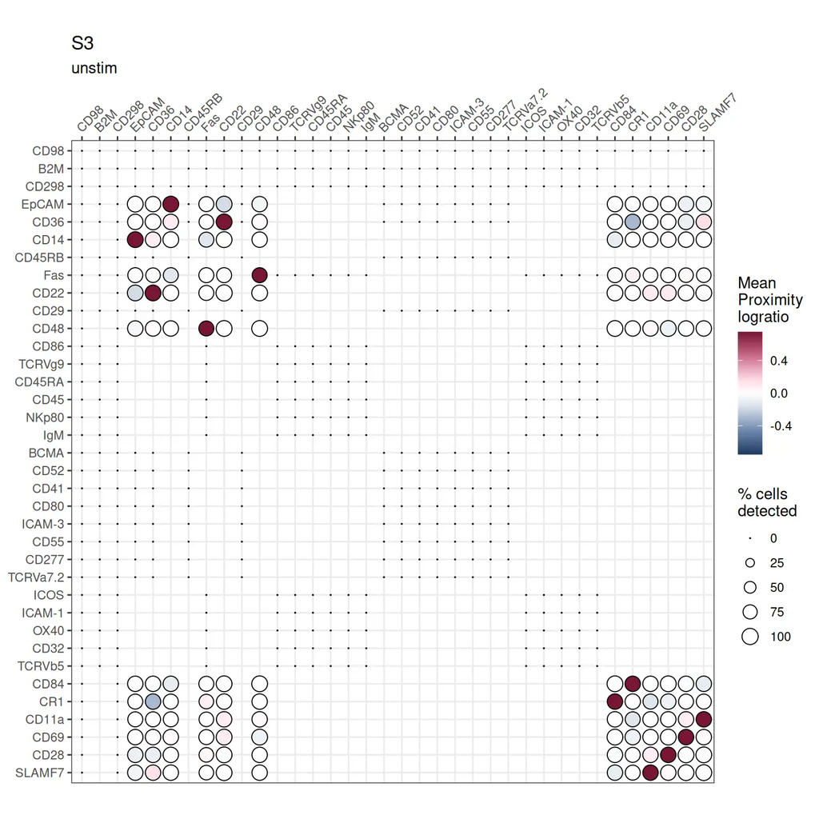

**S4**

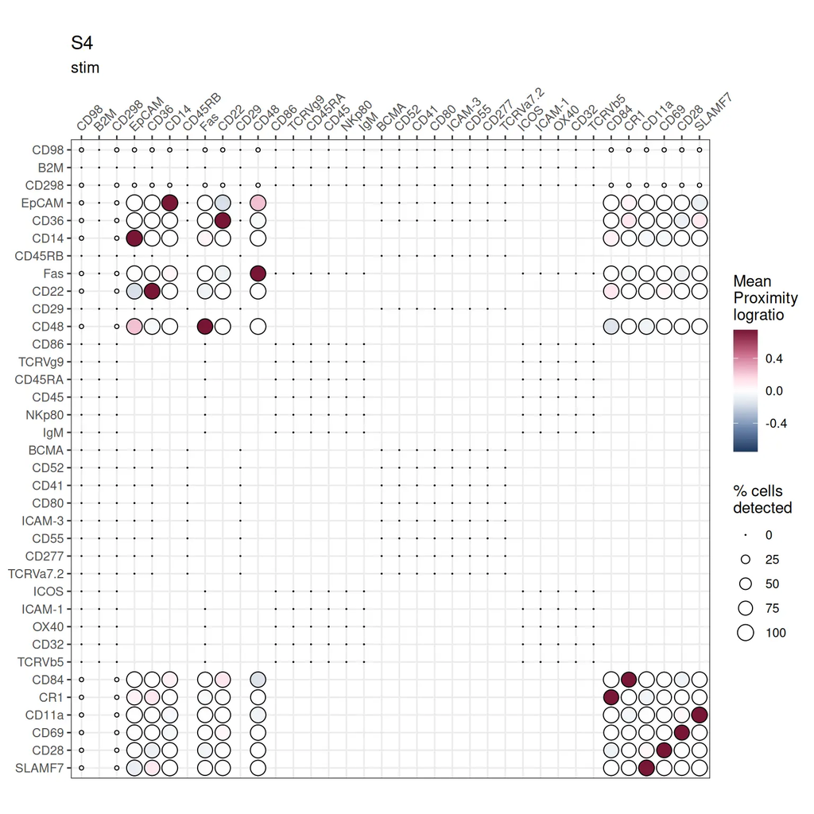

**Per Celltype**

**B**

**S1**

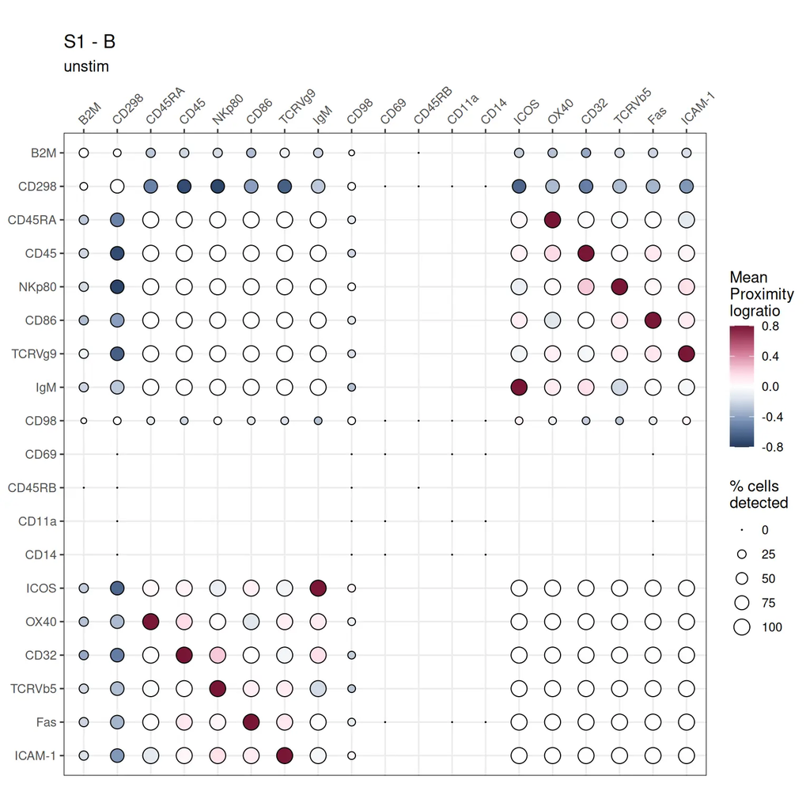

**S2**

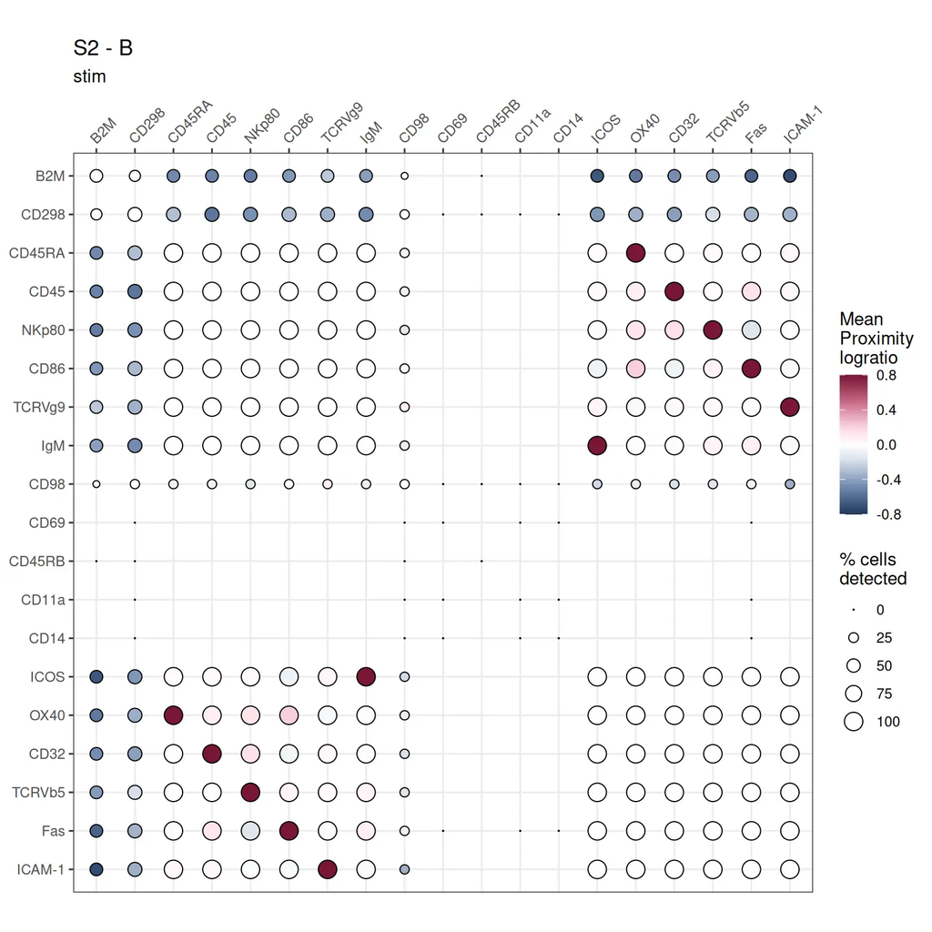

**Platelets**

**S1**

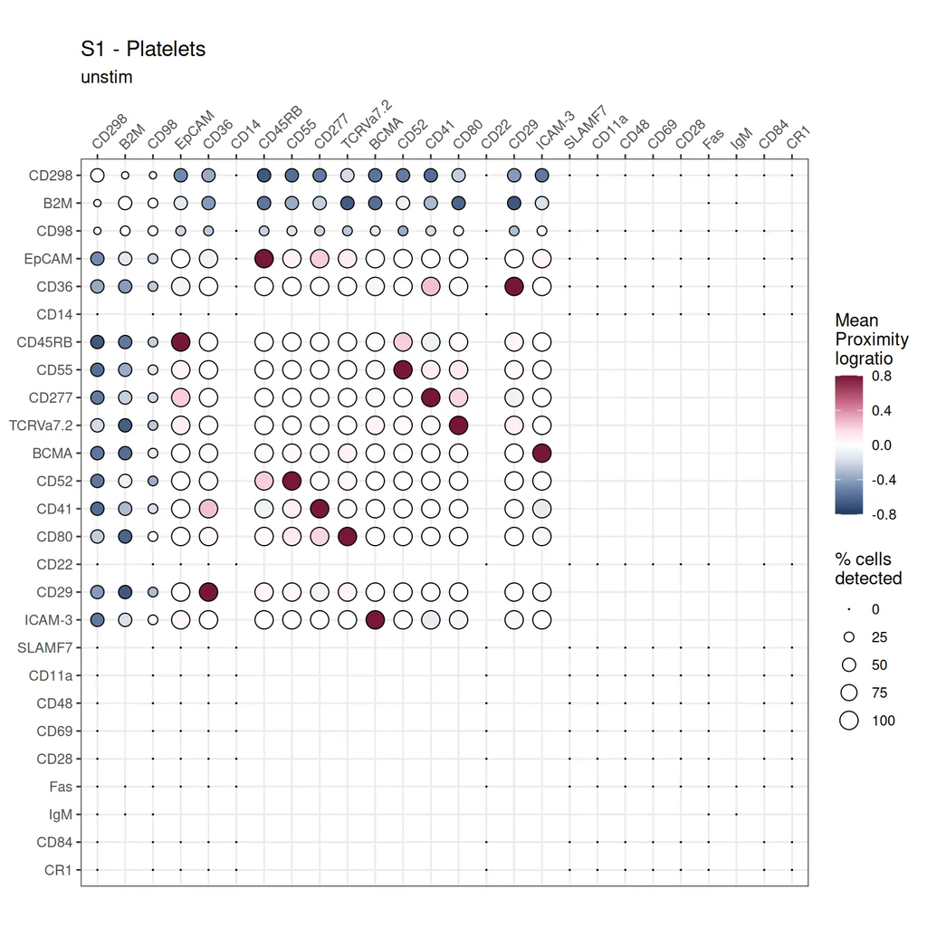

**S2**

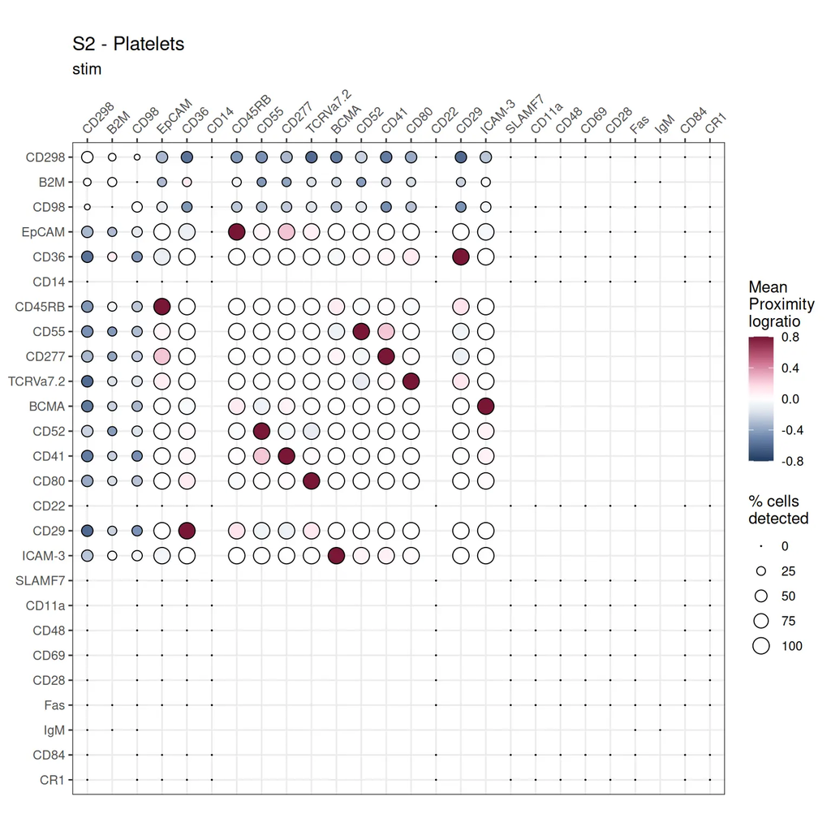

**S3**

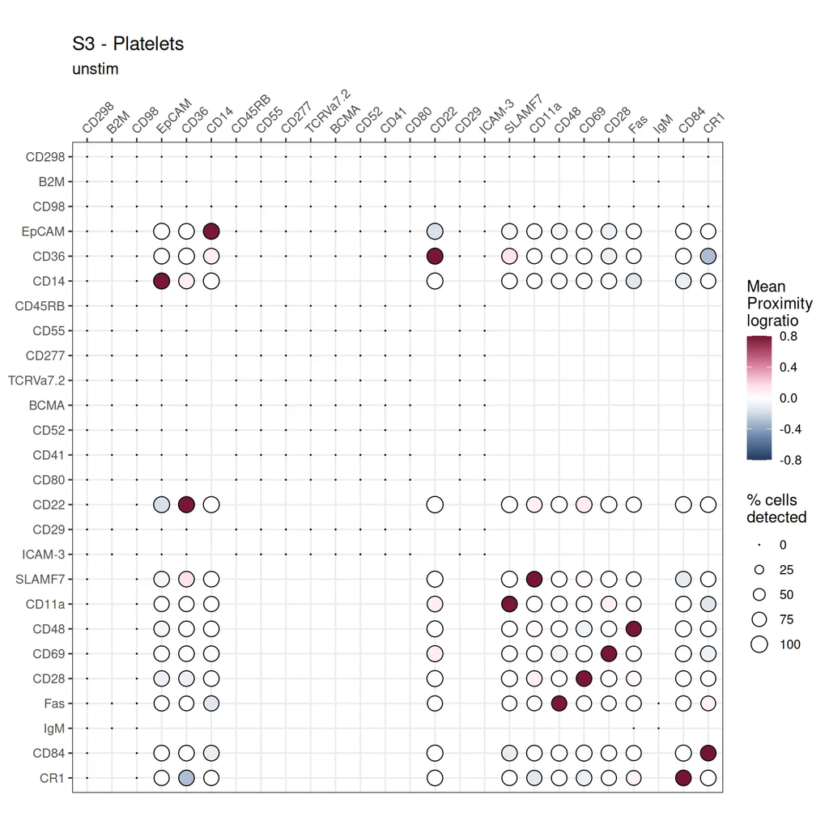

**S4**

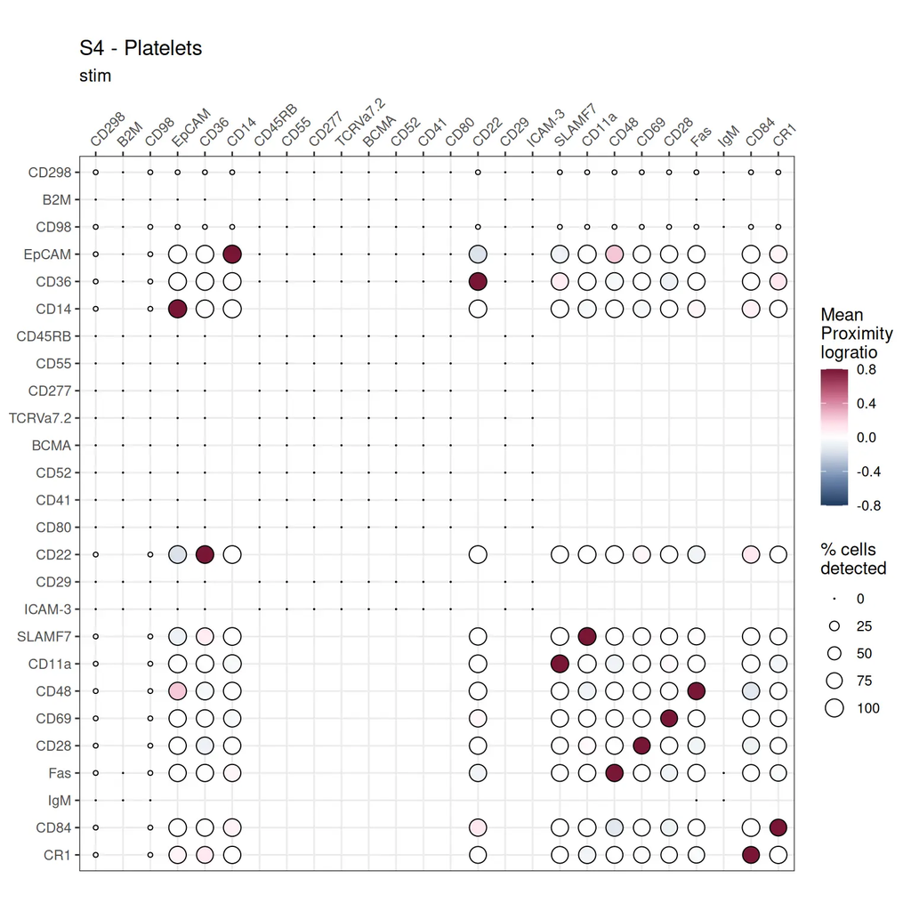

**Run settings**

### Pixelator version

| Sample alias | Sample name | Pixelator version | Panel name |
| --- | --- | --- | --- |
| S1 | sample1 | 0.28.0 | proxiome-v2-immuno-155-v2.0 |
| S2 | sample2 | 0.28.0 | proxiome-v2-immuno-155-v2.0 |
| S3 | sample3 | 0.28.0 | proxiome-v2-immuno-155-v2.0 |
| S4 | sample4 | 0.28.0 | proxiome-v2-immuno-155-v2.0 |

### Run parameters

| Parameter | Value | Default |
| --- | --- | --- |
| control_markers | ['mIgG1', 'mIgG2a', 'mIgG2b'] | ['mIgG1', 'mIgG2a', 'mIgG2b'] |
| do_harmonize | [False] | [False] |
| harmonization_vars | ['condition'] | ['condition'] |
| norm_method | ['CLR'] | ['CLR'] |
| clustering_resolution | [1] | [1] |
| annotation_method | ['nmf'] | ['nmf'] |
| mc_cores | [1] | [1] |
| debug_mode | [False] | [False] |
| test_mode | [True] | ['⚠ FALSE'] |

### Session info

| package | loadedversion |
| --- | --- |
| dplyr | 1.2.1 |
| future | 1.70.0 |
| ggplot2 | 4.0.3 |
| ggplotify | 0.1.3 |
| knitr | 1.51 |
| magick | 2.9.1 |
| pixelatorES | 0.11.0 |
| pixelatorESinternal | 0.21.0 |
| pixelatorR | 0.18.0 |
| purrr | 1.2.2 |

[output cut: 6 more lines]